# Assignment 1-4: Final Module 1 Report

Lucy Hu

20 February 2020

|  | Score |
| --- | --- |
| Q1.1 - Data display | 4/4 |
| Q1.1 - Stat analysis | 4/4 |
| Q1.1 - Summary | 4/4 |
| Q1.2 - Data display | 3/3 |
| Q1.2 - Stat analysis | 3/3 |
| Q1.2 - Summary | 2/2 |
| Total | 20/20 |

##### Comments from Dr. Jager:

- Nice job, Lucy! I really like the graphs you made for both questions and that you were able to put the actual percentages with disease right onto the graphs. This makes it easy to compare the disease risks between smokers and non-smokers within each disease category.
- I agree with your interpretation of your results for Question 1.1. Is there are reason that you chose to just use logistic regression instead of a propensity score approach to answer this question?
- For Question 1.2, you also did a nice job interpreting your results and especially tying the results from the statistical analysis to what was seen in the graphics you made! One comment on your final two paragraphs of interpretation: the interaction doesn’t show us the additional effect of being poor on smoking, it shows the additional effect of being poor on the **relationship between smoking and disease**.

**Due Monday, February 24 @ midnight through Github**

**Question 1.1: How does the risk of disease compare for smokers and otherwise similar non-smokers?**

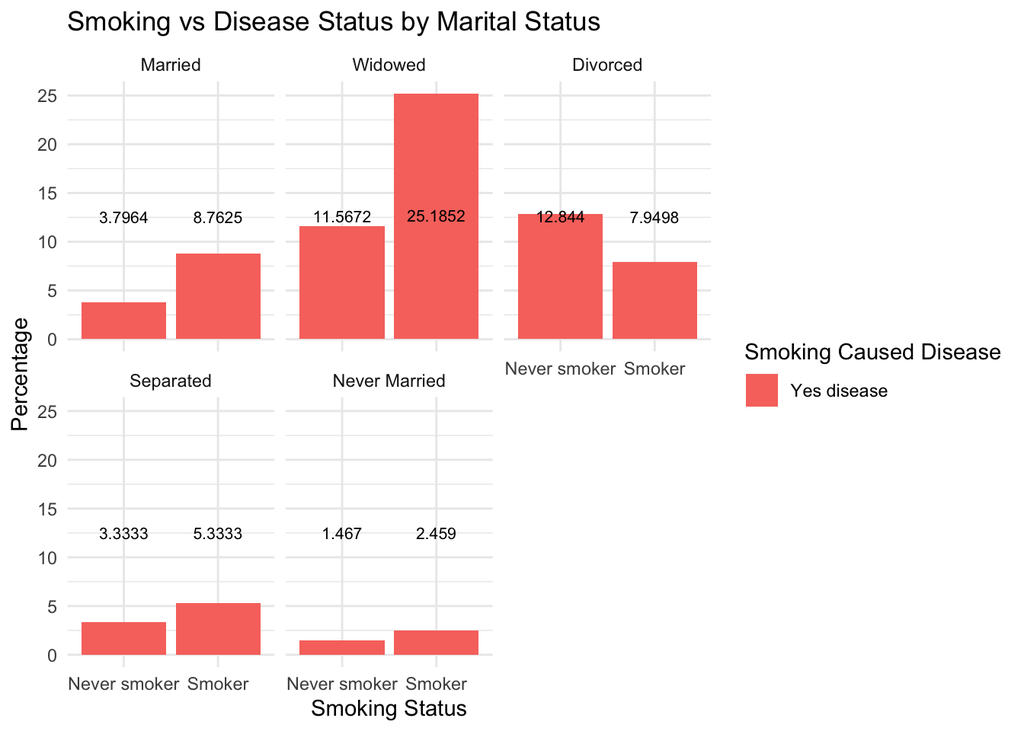

```
##
## Call:
## glm(formula = disease ~ eversmk + marital, family = binomial,
##     data = nmes_data)
##
## Deviance Residuals:
##     Min       1Q   Median       3Q      Max
## -0.7224  -0.4172  -0.2945  -0.2945   2.9396
##
## Coefficients:
##                      Estimate Std. Error z value Pr(>|z|)
## (Intercept)           -3.1162     0.1209 -25.769  < 2e-16 ***
## eversmkSmoker          0.7186     0.1342   5.353 8.65e-08 ***
## maritalWidowed         1.1872     0.1619   7.334 2.24e-13 ***
## maritalDivorced        0.3243     0.2018   1.607    0.108
## maritalSeparated      -0.4071     0.4266  -0.954    0.340
## maritalNever Married  -1.1909     0.3033  -3.926 8.63e-05 ***
## ---
## Signif. codes:  0 '***' 0.001 '**' 0.01 '*' 0.05 '.' 0.1 ' ' 1
##
## (Dispersion parameter for binomial family taken to be 1)
##
##     Null deviance: 2024.6  on 4077  degrees of freedom
## Residual deviance: 1912.9  on 4072  degrees of freedom
## AIC: 1924.9
##
## Number of Fisher Scoring iterations: 6
```

```
##          (Intercept)        eversmkSmoker       maritalWidowed
##           -3.1161593            0.7186230            1.1871692
##      maritalDivorced     maritalSeparated maritalNever Married
##            0.3243390           -0.4071034           -1.1909308
```

```
##          (Intercept)        eversmkSmoker       maritalWidowed
##           0.04432709           2.05160620           3.27778940
##      maritalDivorced     maritalSeparated maritalNever Married
##           1.38311617           0.66557539           0.30393822
```

This analysis compared the risk of disease for smokers vs non-smokers stratified by marital status. Based on the data displays and logistic regression; smoking significantly influenced the risk of disease holding marital status constant. The log odds of disease for smokers is 0.7186 higher than that of non-smokers. Thus the odds of disease for smokers is 2.0516 times that of non-smokers. As can be seen in the graph, the risk of disease was much higher for smokers who were widowed than non-smokers who were widowed and somewhat higher for smokers who were married, separated, or never married compared to non-smokers in those categories. The risk of disease was only higher for non-smokers than in smokers for the divorced category.

**Queston 1.2: Does the contribution of smoking to the risk of disease vary by sex or socio-economic status (SES)?**

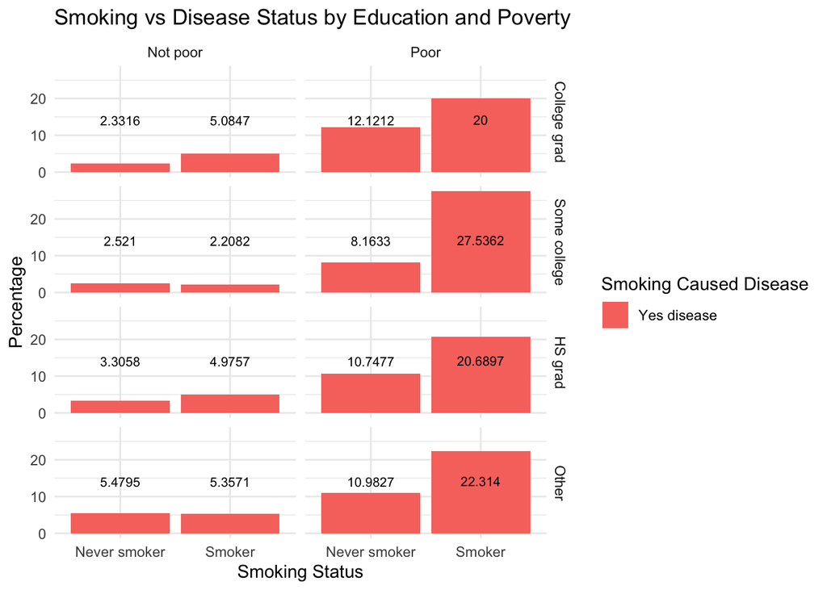

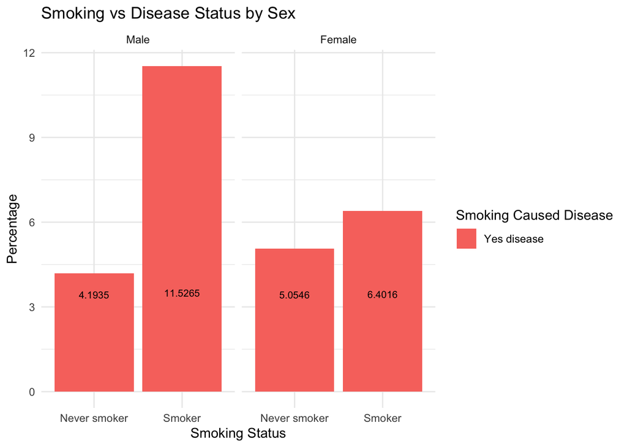

```
##
## Call:
## glm(formula = disease ~ eversmk * educate + eversmk * poor +
##     eversmk * sex, family = binomial(link = "logit"), data = nmes_data)
##
## Deviance Residuals:
##     Min       1Q   Median       3Q      Max
## -0.8127  -0.3524  -0.2635  -0.2381   2.7110
##
## Coefficients:
##                                    Estimate Std. Error z value Pr(>|z|)
## (Intercept)                       -3.604604   0.315609 -11.421  < 2e-16 ***
## eversmkSmoker                      0.870414   0.414552   2.100   0.0358 *
## educateSome college               -0.044586   0.402040  -0.111   0.9117
## educateHS grad                     0.252535   0.328446   0.769   0.4420
## educateOther                       0.430599   0.373848   1.152   0.2494
## poorPoor                           1.192382   0.225499   5.288 1.24e-07 ***
## sexFemale                          0.009264   0.239574   0.039   0.9692
## eversmkSmoker:educateSome college -0.139318   0.522896  -0.266   0.7899
## eversmkSmoker:educateHS grad      -0.266156   0.434670  -0.612   0.5403
## eversmkSmoker:educateOther        -0.494209   0.502649  -0.983   0.3255
## eversmkSmoker:poorPoor             0.603634   0.284431   2.122   0.0338 *
## eversmkSmoker:sexFemale           -0.640544   0.293389  -2.183   0.0290 *
## ---
## Signif. codes:  0 '***' 0.001 '**' 0.01 '*' 0.05 '.' 0.1 ' ' 1
##
## (Dispersion parameter for binomial family taken to be 1)
##
##     Null deviance: 2024.6  on 4077  degrees of freedom
## Residual deviance: 1819.4  on 4066  degrees of freedom
## AIC: 1843.4
##
## Number of Fisher Scoring iterations: 6
```

```
##                       (Intercept)                     eversmkSmoker
##                      -3.604603624                       0.870413529
##               educateSome college                    educateHS grad
##                      -0.044586233                       0.252534784
##                      educateOther                          poorPoor
##                       0.430598872                       1.192382261
##                         sexFemale eversmkSmoker:educateSome college
##                       0.009263715                      -0.139318231
##      eversmkSmoker:educateHS grad        eversmkSmoker:educateOther
##                      -0.266156098                      -0.494208791
##            eversmkSmoker:poorPoor           eversmkSmoker:sexFemale
##                       0.603634300                      -0.640544271
```

```
##                       (Intercept)                     eversmkSmoker
##                        0.02719822                        2.38789811
##               educateSome college                    educateHS grad
##                        0.95639312                        1.28728427
##                      educateOther                          poorPoor
##                        1.53817842                        3.29492123
##                         sexFemale eversmkSmoker:educateSome college
##                        1.00930676                        0.86995114
##      eversmkSmoker:educateHS grad        eversmkSmoker:educateOther
##                        0.76631950                        0.61005340
##            eversmkSmoker:poorPoor           eversmkSmoker:sexFemale
##                        1.82875298                        0.52700551
```

Based on these data displays and logistic regression results, sex and socioeconomic status (defined here by poverty and education levels) do impact the contribution of smoking on the risk of disease. However, education did not significantly modify the effects of smoking on disease rate. As seen in the logistic regression, none of the interaction terms for smoking and education status were significant (Pr(>|z|) of less than 0.05).

Holding everything else constant, the difference in log odds of disease for those who are poor is 0.6036 higher than those who are not poor. Thus the odds ratio for the poor is 1.8288 times that of those who are not poor of similar education and sex, which shows the additional affect of being poor on smoking. This can be seen in the data display as the ratios of lung cancer in smokers to non-smokers amongst the poor group was greater than that of the not-poor group.

Holding everything else constant, the difference in log odds of disease for females is 0.6405 lower than the log odds of disease for males. Thus the odds ratio for females is 0.527 times that of males of similar education and poverty status, which shows the additional affect of being female on smoking. This can be seen in the graphical display as the percentage of lung cancer in male smokers was over twice the percentage of lung cancer in male non-smokers. The percentages of lung cancer in females were relatively comparable between smokers and non-smokers.